# Coursework Report

*N* total clean: 128

| Group | *N* | *M*<sub>age</sub> | *M*<sub>rating</sub> |
| --- | --- | --- | --- |
| Control | 66 | 20.6 | 5.89 |
| Experim | 62 | 20.7 | 7.12 |

**Main analysis results**

*t*(126) = -8.93, *p* < .001

# Coursework Report

Analysing Data, Spring 2020

```
## tibble [150 x 6] (S3: tbl_df/tbl/data.frame)
##  $ ID        : Factor w/ 150 levels "AFRN","APGB",..: 25 36 139 149 42 136 111 3 67 47 ...
##  $ YEARS     : chr [1:150] "24" "20" "20" "22" ...
##  $ GROUP     : Factor w/ 3 levels "control","experimental",..: 1 1 1 1 1 1 1 1 1 1 ...
##  $ QUESTION_1: num [1:150] 4 6 3 5 7 7 5 6 5 6 ...
##  $ QUESTION_2: num [1:150] 7 7 8 6 5 8 8 6 6 3 ...
##  $ QUESTION_3: num [1:150] 7 5 5 6 6 7 5 7 7 4 ...
```

```
## .
## 10 15 16 17 18 19 1r 20 21 22 23 24 25 26  6
##  1  1  4 12 16 27  1 26 19 18  8  8  4  2  1
```

```
## tibble [150 x 6] (S3: tbl_df/tbl/data.frame)
##  $ ID        : Factor w/ 150 levels "AFRN","APGB",..: 25 36 139 149 42 136 111 3 67 47 ...
##  $ YEARS     : num [1:150] 24 20 20 22 20 20 19 21 22 18 ...
##  $ GROUP     : Factor w/ 3 levels "control","experimental",..: 1 1 1 1 1 1 1 1 1 1 ...
##  $ QUESTION_1: num [1:150] 4 6 3 5 7 7 5 6 5 6 ...
##  $ QUESTION_2: num [1:150] 7 7 8 6 5 8 8 6 6 3 ...
##  $ QUESTION_3: num [1:150] 7 5 5 6 6 7 5 7 7 4 ...
```

```
##        ID          YEARS             GROUP      QUESTION_1    QUESTION_2     QUESTION_3
##  AFRN   :  1   Min.   : 6   control     :73   Min.   :3.0   Min.   :3.00   Min.   :3.00
##  APGB   :  1   1st Qu.:19   experimental:76   1st Qu.:6.0   1st Qu.:6.00   1st Qu.:5.00
##  ATDA   :  1   Median :20   experimentl : 1   Median :6.5   Median :7.00   Median :6.00
##  AUGA   :  1   Mean   :20                     Mean   :6.5   Mean   :6.67   Mean   :6.39
##  AUWH   :  1   3rd Qu.:22                     3rd Qu.:8.0   3rd Qu.:7.75   3rd Qu.:7.00
##  AYVT   :  1   Max.   :26                     Max.   :9.0   Max.   :9.00   Max.   :9.00
##  (Other):144   NA's   :3
```

```
## [1] 19
```

```
##        ID          YEARS               GROUP      QUESTION_1     QUESTION_2    QUESTION_3
##  AFRN   :  1   Min.   :18.0   control     :66   Min.   :3.00   Min.   :3.0   Min.   :3.00
##  APGB   :  1   1st Qu.:19.0   experimental:61   1st Qu.:5.00   1st Qu.:6.0   1st Qu.:5.00
##  ATDA   :  1   Median :20.0   experimentl : 1   Median :6.50   Median :7.0   Median :6.00
##  AUGA   :  1   Mean   :20.7                     Mean   :6.47   Mean   :6.6   Mean   :6.38
##  AUWH   :  1   3rd Qu.:22.0                     3rd Qu.:8.00   3rd Qu.:7.0   3rd Qu.:7.00
##  AYVT   :  1   Max.   :26.0                     Max.   :9.00   Max.   :9.0   Max.   :9.00
##  (Other):122
```

```
## # A tibble: 128 x 6
##    ID    YEARS GROUP QUESTION_1 QUESTION_2 QUESTION_3
##    <lgl> <lgl> <lgl> <lgl>      <lgl>      <lgl>
##  1 FALSE FALSE FALSE FALSE      FALSE      FALSE
##  2 FALSE FALSE FALSE FALSE      FALSE      FALSE
##  3 FALSE FALSE FALSE FALSE      FALSE      FALSE
##  4 FALSE FALSE FALSE FALSE      FALSE      FALSE
##  5 FALSE FALSE FALSE FALSE      FALSE      FALSE
##  6 FALSE FALSE FALSE FALSE      FALSE      FALSE
##  7 FALSE FALSE FALSE FALSE      FALSE      FALSE
##  8 FALSE FALSE FALSE FALSE      FALSE      FALSE
##  9 FALSE FALSE FALSE FALSE      FALSE      FALSE
## 10 FALSE FALSE FALSE FALSE      FALSE      FALSE
## # ... with 118 more rows
```

```
##   [1] 0 0 0 0 0 0 0 0 0 0 0 0 0 0 0 0 0 0 0 0 0 0 0 0 0 0 0 0 0 0 0 0 0 0 0 0 0 0 0 0 0 0 0 0 0 0 0 0 0 0 0 0 0 0 0 0 0 0 0 0 0 0 0 0 0 0 0 0 0 0 0 0 0 0
##  [75] 0 0 0 0 0 0 0 0 0 0 0 0 0 0 0 0 0 0 0 0 0 0 0 0 0 0 0 0 0 0 0 0 0 0 0 0 0 0 0 0 0 0 0 0 0 0 0 0 0 0 0 0 0 0
```

```
##        ID          YEARS               GROUP      QUESTION_1     QUESTION_2    QUESTION_3
##  AFRN   :  1   Min.   :18.0   control     :66   Min.   :3.00   Min.   :3.0   Min.   :3.00
##  APGB   :  1   1st Qu.:19.0   experimental:61   1st Qu.:5.00   1st Qu.:6.0   1st Qu.:5.00
##  ATDA   :  1   Median :20.0   experimentl : 1   Median :6.50   Median :7.0   Median :6.00
##  AUGA   :  1   Mean   :20.7                     Mean   :6.47   Mean   :6.6   Mean   :6.38
##  AUWH   :  1   3rd Qu.:22.0                     3rd Qu.:8.00   3rd Qu.:7.0   3rd Qu.:7.00
##  AYVT   :  1   Max.   :26.0                     Max.   :9.00   Max.   :9.0   Max.   :9.00
##  (Other):122
```

```
## # A tibble: 128 x 6
##    ID    YEARS GROUP   QUESTION_1 QUESTION_2 QUESTION_3
##    <fct> <dbl> <fct>        <dbl>      <dbl>      <dbl>
##  1 DMEF     24 control          4          7          7
##  2 FEGS     20 control          6          7          5
##  3 YIZZ     20 control          3          8          5
##  4 ZQVP     22 control          5          6          6
##  5 GERK     20 control          7          5          6
##  6 XQKG     20 control          7          8          7
##  7 TVPN     19 control          5          8          5
##  8 ATDA     21 control          6          6          7
##  9 KHVB     22 control          5          6          7
## 10 GQCO     18 control          6          3          4
## # ... with 118 more rows
```

```
##        ID          YEARS               GROUP      QUESTION_1     QUESTION_2    QUESTION_3
##  AFRN   :  1   Min.   :18.0   control     :66   Min.   :3.00   Min.   :3.0   Min.   :3.00
##  APGB   :  1   1st Qu.:19.0   experimental:62   1st Qu.:5.00   1st Qu.:6.0   1st Qu.:5.00
##  ATDA   :  1   Median :20.0                     Median :6.50   Median :7.0   Median :6.00
##  AUGA   :  1   Mean   :20.7                     Mean   :6.47   Mean   :6.6   Mean   :6.38
##  AUWH   :  1   3rd Qu.:22.0                     3rd Qu.:8.00   3rd Qu.:7.0   3rd Qu.:7.00
##  AYVT   :  1   Max.   :26.0                     Max.   :9.00   Max.   :9.0   Max.   :9.00
##  (Other):122
```

```
## # A tibble: 1 x 4
##    mean    sd   min   max
##   <dbl> <dbl> <dbl> <dbl>
## 1  20.7  1.98    18    26
```

```
## # A tibble: 2 x 5
##   GROUP            n  perc mean_YEARS sd_YEARS
##   <fct>        <int> <dbl>      <dbl>    <dbl>
## 1 control         66  51.6       20.6     1.94
## 2 experimental    62  48.4       20.7     2.05
```

| GROUP | n | perc | mean_YEARS | sd_YEARS |
| --- | --- | --- | --- | --- |
| control | 66 | 51.6 | 20.6 | 1.94 |
| experimental | 62 | 48.4 | 20.7 | 2.04 |

Table 1 *Descriptive statistics by Group*

| Group | *N* | % | *M*<sub>age</sub> | *SD*<sub>age</sub> |
| --- | --- | --- | --- | --- |
| control | 66 | 51.6 | 20.6 | 1.94 |
| experimental | 62 | 48.4 | 20.7 | 2.05 |

```
## # A tibble: 128 x 5
## # Groups:   ID [128]
##    ID    QUESTION_1 QUESTION_2 QUESTION_3 QUESTION_comp
##    <fct>      <dbl>      <dbl>      <dbl>         <dbl>
##  1 DMEF           4          7          7          6
##  2 FEGS           6          7          5          6
##  3 YIZZ           3          8          5          5.33
##  4 ZQVP           5          6          6          5.67
##  5 GERK           7          5          6          6
##  6 XQKG           7          8          7          7.33
##  7 TVPN           5          8          5          6
##  8 ATDA           6          6          7          6.33
##  9 KHVB           5          6          7          6
## 10 GQCO           6          3          4          4.33
## # ... with 118 more rows
```

```
##    Min. 1st Qu.  Median    Mean 3rd Qu.    Max.
##    4.00    6.00    6.33    6.48    7.33    8.67
```

[output not shown]

[output cut: 356 more lines]

[output not shown]

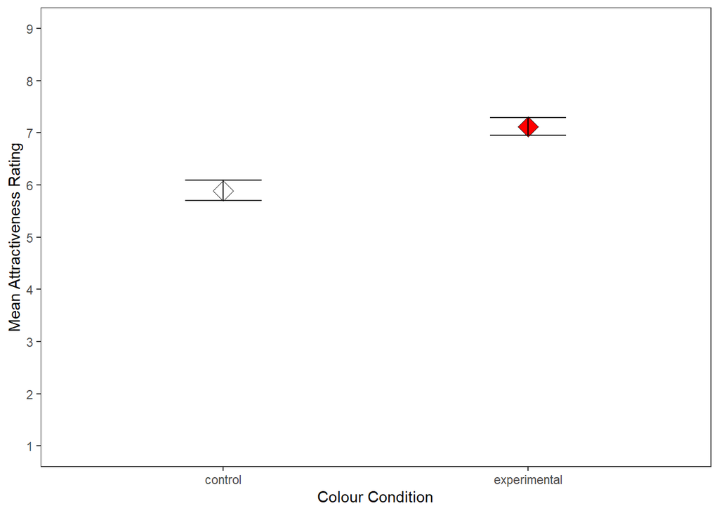

```
##
##  Two Sample t-test
##
## data:  QUESTION_comp by GROUP
## t = -9, df = 126, p-value = 0.000000000000004
## alternative hypothesis: true difference in means is not equal to 0
## 95 percent confidence interval:
##  -1.502 -0.957
## sample estimates:
##      mean in group control mean in group experimental
##                       5.89                       7.12
```

# Methods

## Participants

Data from 150 participants ((*M*<sub>Age</sub> = 20.66, *SD*<sub>Age</sub> = 1.98 , *Range*<sub>Age</sub> = 18 -26) were initially collected anonymously as part of Elliot’s et al. (2010) replication, investigating the colour red linked to attractiveness. 22 participants were exluded in total, where 19 of them were under the age of 18 and thus removed to avoid using minors for ethical reasons.The other 3 were also removed automitacally, because they had missing values in the dataset and so were not included in the sample either. Overall, 128 participants were included in the dataset and hence to the calculation of results.The age breakdown by group is given on Table 1.

Table 1 *Descriptive statistics by Group*

| Group | *N* | % | *M*<sub>age</sub> | *SD*<sub>age</sub> |
| --- | --- | --- | --- | --- |
| control | 66 | 51.6 | 20.6 | 1.94 |
| experimental | 62 | 48.4 | 20.7 | 2.05 |

## Measures

Perceived attractivness was measured through three questions: “How attractive do you think this person is?” “How pleasant is this person to look at?” and “If I were to meet the person in this picture face to face, I would think he is attractive.”, used also in the original experiment (Elliot et al, 2010). The questions were rated on 9-point Likert scales ranging from 1 (not at all attractive) to 9 (extremely attractive),and scores were averaged to form a composite score.

## Design

The research question investigated in this replication is whether the colour red influences attractivness, and more specifically if women perceive men more attractive in relation to the colour red. To operationalise this, participants were shown the same picture of a moderately attractive men in either a neutral colour frame (white) or a in a red frame depending on the condition they were in. So, colour (red or white) was the independant categorical variable that was manipulated across the two conditions (control or experimental) in order to test attractiveness. Attractivness was the continuous dependant variable that was measured through the three questions reported above in a Likert scale from 1-9 which was self-reported by the participants. In the analysis of the oresent replication the composite score of the three rating scales was calculated in order to compare the mean rating across the two groups. A mean of 1 would mean that participants found did not found the men attractive at all whereas a mean of 9 would mean that they found the men extremely attractive. So, the operational hypothesis is that women viewing a white frame around a moderately attractive men compared to a red frame may influence the meanratings of his attractiveness. To test this hypothesis an independent-samples t-test will be used.

# Results

Mean Attractiveness Rating was calculated by averaging the three questions, measured in a Liker-scale, to form a composite score. This was calculated by taking the mean score of the three questions for every participant (*QUESTION_comp* = 6.48). An independent-measures t-test examining the influence of red color, compared to white on perceived attractivenes of women towards men revealed a significant color effect, as predicted ( (*M*<sub>diff</sub> = -1.23, 95% CI [-1.5, -0.96], *t* (126) = -8.93, *p* = < .001).). So, participants in the red-frame condition gave higher mean ratings of attractiveness (*M* = 7.12), compared to participants in the white-frame condition (*M* = 5.89), suggesting that the color red actually influenced women’s perceived attractiveness towards men, as illustrated in the figure provided, plotting the mean difference of attractiveness ratings between the two groups. Thus, the results from this replication supports the original findings of Elliot et al(2010) and suggests that color influences attractiveness without participant’s awareness.

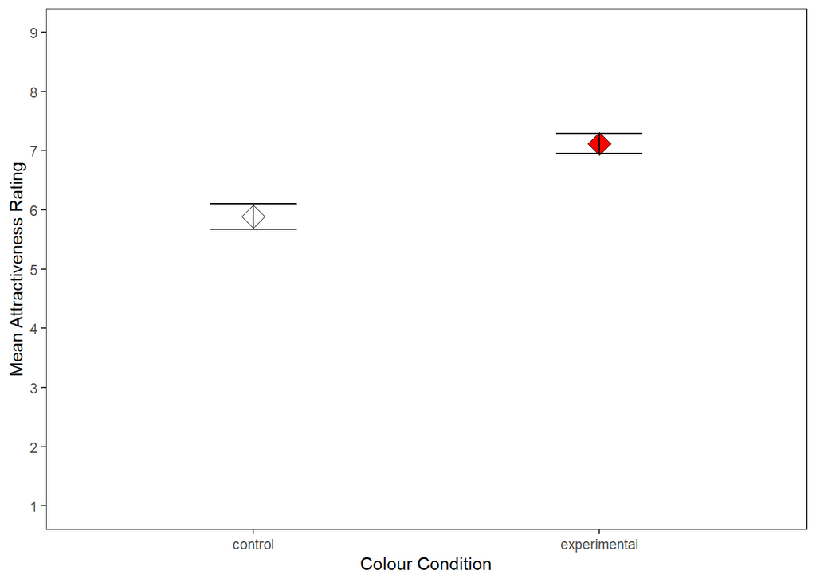

# Discussion

This study aimed to replicate one of the original experiments on the red effect conducted by Elliot et al (2010) and more specifically Experiment 1. The same methodology was followed as the original experiment, with large sample size and found that there was a statistically significant difference between the two groups, meaning that women who saw a man in a red frame rated them more attractive overall, compared to women viewing the same men on a white background supporting the original findings and consequently the red effect. An important aspect of this replication is the re-examination and confirmation of the red effect specific to women’s attractions to men since most research on the red effect studies men’s perceptions of attractiveness towards women and research on the opposite sexes are limited. Thus far, mixed results are obtained regarding the red effect where some studies support the red effect and others criticize it after finding null results. For example, Elliot and Niesta (2008) found that color red has a significant impact on opposite-sex ratings of attractiveness. Across four experiments they found that a photo of a woman in front of a red background was rated as more attractive and sexually desirable by men. However, again the study shows significant results only for perceived attractiveness of men towards women and not the opposite. Moreover, Pazda and Elliot (2016) contributed to research on the red effect by showing that processing the word red can enhance women’s perception of men’s attractiveness without actually perceiving the color red, demonstrated across three experiments. However, there is also contradictory research like the one of Schwarz and Singer (2013) who studied the red effect by distinguishing women from reproductive age and thus both young and older women where tested in front of a red or white background. Results showed no support for the red effect as there was no difference between the physical attractiveness ratings for either the old or young woman. Additionally, Elliot, Tracy, Pazda, and Beall (2013) studied potential universality of the red effect in human mate preferences in a relatively isolated community in Burkina Faso but found no significant difference in sexual interest across the two conditions. The above research discussed, used the background color manipulation to study the red effect as the original study of Elliot et al (2010) did and consequently this replication, resulting in mixed results and questioning whether the color red actually make men more attractive, compared to other colors and the red effect in general. There are also other experimental manipulations to study the red effect such as the color of clothing that is possibly more ecologically valid, compared to background color. For example, Peperkoorn et al (2016) conducted a replication of Elliot and Pazda (2012) experiments, who found significant results for the red effect. However, no significant results emerged in Peperkoorn’s replications of the original studies, since the women wearing red were not deemed more attractive or sexually desirable by men, compared to women in white or black clothing. Therefore, more replications of the original experiments are needed to establish robust results and determine whether the red effect actually exists in real-life. The present replication agrees and supports the findings of the original experiment conducted by Elliot et al (2010). However, these findings show no evidence of the underlying mechanism behind the red effect. Elliot et al (2010) argued that the underlying factor of perceiving men more attractive in conjunction with color red is status, since red is linked to strength, power, and competitive dominance (Little & Hill, 2007; Schaie, 1961; Wexner, 1954). Also there is an evolutionary explanation, suggesting that status is associated with higher testosterone (e.g Archer, 2006) and thus a display of red increases women’s preferences towards men. Elliot et al (2010) investigated this by using the experimental-causal-chain meaning that status was manipulated first and then women rated the attractiveness of high or low status men, and found that high-status men were perceived more attractive, supporting the theory. However, there are several possibilities that could account for the predisposition towards red and more replications are needed to study this specific underlying factor to draw any conclusions. There are several limitations in the present replication as well as research on the red effect in general. Firstly, the sample comprised mostly of undergraduate students from western cultures, and thus theory was not tested on cross-culturally sample as it argues that it applies to. However, the sample size was remarkably higher since 128 participants were recruited at last compared to only 21 participants used in the original experiment. This counter-balances representativeness of the sample to the general population, thus making generalization of results more possible. Another important issue of this replication and research on the ref effect in general is ecological validity and the extent to which results are generalizable. Red effect is tested mostly though laboratory experiments using artificial manipulations like background frame or clothing color. However, according to theory red has a physical based influence on attractiveness, specifically though skin’s vascularization that may act as a sexual signal for women, maximizing reproductive success (Elliot et al, 2010). Thus, future research is needed to test the influence of red displayed on the skin to determine the generalizability of the present results, even if such research can be technically challenging to conduct. For example, Roberts et al (2004) found that women are rated as more attractive during ovulation which was mediated by increase in vascularization on the face or body. More extended research is needed on this field to determine whether the red effect can be applied in real-life. Furthermore, this replication lacks ecological validity due to the methodology and specifically the measure of attractiveness. In the original study and the replication as well a single photo of a moderately attractive man was showed. However, research suggests that when several negative characteristics are present (e.g., facial asymmetry and a high waist-to-hip ratio), the color red used as a sexual signal may trigger repulsion instead of attraction (Elliot and Niesta, 2008). So, results may be significant for moderately or highly attractive men but the phenomenon is not studied for highly unattractive men and thus does not take into account the variability of appearance found in real life. Also Elliot et al (2010) and consequently this replication neglected further other important factors that may influence perceived attractiveness such as apparel style or “wearer effect”, meaning that the fact that wearing red only may change the wearer’s feeling and manner, influencing the observers rating. This effect is actually shown in several studies by Roberts, Owen, & Havlicek (2010) and Hesslinger, Goldbach, & Carbon (2015), indicating that we cannot distinguish these confounding variables from the red effect in real life. Future research should focus on conducting studies with diverse and large sample of models to be as realistic as possible. For example a recent study conducted by Young (2015) used 40 different images and found that the red effect was observed only female attractive faces and not for unattractive female faces, questioning the generalizability of the red effect. There are also some methodological limitations in the present replication that should be taken into consideration for further replications in the red effect. Firstly, perceived attractiveness was measured through three questions, rated in a Likert-scale, where one of them was: “How pleasant is this person to look at?”. It is preferred however, to distinguish between perceived attractiveness, likeability and sexual desire as they may measure other positive characteristics apart from attractiveness. For example, Elliot and Niesta (2008) found, the red effect was observed for men’s perceptions of women’s attractiveness; but did not influence their perceptions of other positive characteristics that tend to covary with attractiveness in the beautiful-is-good. Moreover, there is a practical problem if the red effect only emerges with an exposure time of 5 seconds, as studied in this replication since in real life encounter with another person lasts more than 5 seconds. More studies are needed to determine if the red effect is restricted by viewing time, by increasing the exposure time significantly. Finally, results could be attributed due to the simple fact that people prefer chromatic colors over achromatic colors like white (Axelsson, 2007). So, more replications should be done testing other chromatic colors. Finally, research on the red effect conducted by Elliot et al (2010), including the study that was replicated here is criticized for publication bias and should be considered. Francis et al (2013) criticized Elliot’s work by arguing that either in some experiments researchers failed to accept the null hypothesis, known as Type 1 error or that experiments were overestimated regarding their true effects size. This was also attributed to the small sample sizes Elliot used. However, other replications as well with larger sample sizes did not found statistically significant results for the red effect

(Hesslinger, Goldbach, & Carbon, 2015). Nonetheless, there are also some replications conducted by independent laboratories like the studies by Roberts, Owen, and Havlicek (2010), who in three experiments showed supporting evidence for the red effect, as well as the replication presented here. The color red has recently received empirical attention in several domains like achievement and regularly appear in the popular media but typically statements around the study of the color red are general and context free. Thus, empirical research on color and psychological functioning must be theoretically grounded and carefully conducted in order to draw any conclusions. The present study managed to replicate successfully the original experiment by Elliot et al (2010) and found supporting evidence for the red effect. However, mixed results are obtained in this field of study and more replications are needed to establish robust results and studies with higher ecological validity should be conducted to be able to generalize results in real life settings. This is especially important since, it has important implications in real life as it could influence sales, advertising (e.g., Aslam, 2006), public relations, fashion (e.g., Ellinwood, 2011), and most importantly relationships.

# References

Archer, J. (2006). Testosterone and human aggression: An evaluation of the challenge hypothesis. Neuroscience and Biobehavioral Reviews, 30, 319–345.

Aslam, M. M. (2006). Are you selling the right colour? A cross cultural review of colour as a marketing cue. Journal of Marketing Communications, 12, 15–30.

Axelsson, O. (2007). Towards a psychology of photography: Dimensions underlying aesthetic appeal of photographs. Perceptual and Motor Skills, 105, 411–434.

Ellinwood, J. G. (2011). Fashion by design. New York, NY: Fairchild Books.

Elliot, A. J., & Maier, M. A. (2013). The red-attractiveness effect, applying the Ioannidis and Trikalinos (207b) test, and the broader scientific context. Journal of Experimental Psychology: General, 142, 297–300.

Elliot, A. J., & Niesta, D. (2008). Romantic red: Red enhances mens attraction to women. Journal of Personality and Social Psychology, 95(5), 1150–1164. Elliot, A. J., Kayser, D. N., Greitemeyer, T., Lichtenfeld, S., Gramzow, R. H., Maier, M. A., & Liu, H. (2010). Red, rank, and romance in women viewing men. Journal of Experimental Psychology: General, 139(3), 399–417. Elliot, A. J., Pazda, A. D. (2012). Dressed for sex: Red as a female sexual signal in humans. PLoS One, 7, e34607.

Elliot, A. J., Tracy, J. L., Pazda, A. D., Beall, A. T. (2013). Red enhances women’s attractiveness to men: First evidence suggesting universality. Journal of Experimental Social Psychology, 49, 165–168.

Francis, G. (2013). Publication bias in “Red, rank, and romance in women viewing men,” by Elliot et al. (2010). Journal of Experimental Psychology: General, 142, 292–296.

Hesslinger, V.M., Goldbach, L. & Carbon, C. (2015).Men in red: A reexamination of the red-attractiveness effect. Psychon Bull Rev 22, 1142–1148.

Little, A. C., & Hill, R. A. (2007). Attribution to red suggests special role in dominance signalling. Journal of Cultural and Evolutionary Psychology, 5, 87–94.

Pazda, A. D., & Elliot, A. J. (2016). Processing the Word Red can Enhance Women’s Perceptions of Men’s Attractiveness. Current Psychology, 36(2), 316–323.

Peperkoorn, L. S., Roberts, S. C., & Pollet, T. V. (2016). Revisiting the Red Effect on Attractiveness and Sexual Receptivity. Evolutionary Psychology, 14(4), 147470491667384. Roberts, S. C., Havlicek, J., Flegr, J., Hruskova, M., Little, A. C., Jones, B. C., et al. (2004). Female facial attractiveness increases during the fertile phase of the menstrual cycle. Proceedings of the Royal Society of London, 271, S270–S272.

Roberts, S. C., Owen, R. C., Havlicek, J. (2010). Distinguishing between perceiver and wearer effects in clothing color-associated attributions. Evolutionary Psychology, 8, 350–364.

Schaie, K. W. (1961). Scaling the association between colors and moodtones. American Journal of Psychology, 74, 266–273.

Schwarz, S., Singer, M. (2013). Romantic red revisited: Red enhances men’s attraction to young, but not menopausal women. Journal of Experimental Social Psychology, 49, 161–164.

Wexner, L. B. (1954). The degree to which colors (hues) are associated with mood-tones. Journal of Applied Psychology, 6, 432–436.

Young, S. G. (2015). The effect of red on male perceptions of female attractiveness: Moderation by baseline attractiveness of female faces. European Journal of Social Psychology, 45, 146–151.